# R is dope AF

Matthew Malishev<sup>1</sup>* *<sup>1</sup> Department of Biology, Emory University, 1510 Clifton Road NE, Atlanta, GA, USA, 30322

Date: 2018-12-19  
R version: 3.5.0  
*Corresponding author: matthew.malishev@gmail.com  
This document can be found at https://github.com/darwinanddavis/SchistoIBM/tree/master/mac

R session info

```r
params$session
```

# Overview

This document showcases why `R` is **dope**.

You can write in-line `code`, equations like this $E = mc^{2}$, create links to your [website](https://github.com/darwinanddavis).

# Just like LateX, but *more versatile*.

## Create quoted text

> Pump the bass in the trunk //  
> It rattled like a baby hand //  
> Except this toy cost 80 grand //  
> And I’m crazy tan, from all the places that I’ve been //  
> Just from writing words with a pen //

## Define equations

$$t'=
\frac
{1}
{
\sqrt{1 - \frac
{v^{2}}
{c^{2}}
}
}$$

Accordingly, we write the eigenfunction of a spinless particle as the superposition of plane wave states of momentum ($\pi$) and energy ($Ej$) having amplitudes $a(\pi,Ej)$

$$\phi n(r,t) =
\sum_{i, j} a(p_{i},E_{j})
e^{
\frac{i}
{h}
(p_{i} \cdot r - E_{j}t)
}$$

where, for convenience, we have suppressed the eigenfunction indices in $\phi n(r,t)$ and $an(\pi,Ej)$. Using periodic boundary conditions, the normalization of $\phi n(r,t)$ in (1) yields

$$\frac
{1}
{V_{o}T_{o}h^{4}}
\int \phi \cdot (r,t) \phi (r,t)d^{3}rdt = \sum a \cdot (p_{i},E_{j})a(p_{i},E_{j}) = 1$$

## Embed images/gifs:

[figure not shown]

.

## Create, alter, and imbed plots

### (with associated code)

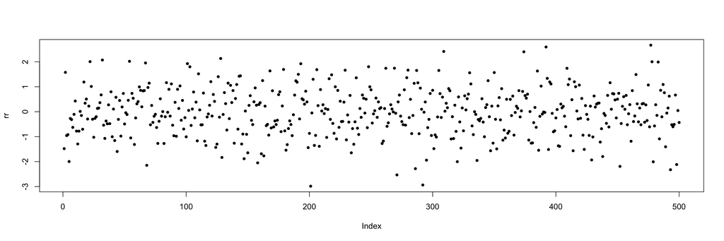

```r
set.seed(12)
rr <- rnorm(500)
plot(rr,pch=20)
```

```r
require(viridis)
set.seed(12)
rr <- rnorm(500)
plot(rr,las=1,bty="n",col=adjustcolor(magma(50),0.5),pch=20,cex=runif(10, 1, 5),
     main="Some randomly distributed data, \nbut plot better")
```

[output not shown]

## And tables

Table 1. Definitions of model parameters for individual hosts and **parasites**. Dimensions and units: -, dimensionless; cm, centimetres; J, Joules; L, length.

| Parameter | Definition | Dimension (unit) |
| --- | --- | --- |
| *L* | structural length | cm |
| *ee* | scaled reserve density | J (cm<sup>3</sup>) |
| *D* | host development | — |
| *RH* | energy in reproduction buffer | J |

## Embed code from different languages

### This is `R` code

```r
if(pck==1){
  p<-c("rJava", "RNetLogo"); remove.packages(p)
  # then install rJava and RNetLogo from source
  install.packages("rJava", repos = "https://cran.r-project.org/")
  install.packages("RNetLogo", repos = "https://cran.r-project.org/")
}
```

### `shell/bash`

```bash
echo "Hello Bash!"
pwd # check working dir
git init # initialise git
```

### Octave (and MATLAB from the `RMatlab` package).

[`RMatlab documentation`](https://cran.r-project.org/web/packages/R.matlab/index.html).

```matlab
b = [4; 9; 2] # Column vector
A = [ 3 4 5;
      1 3 1;
      3 5 9 ]
x = A \ b     # Solve the system Ax = b
```

### HTML

```html
<!-- links-->
        <div class="footer">
            <a href="dd_feed.html"
            class="transition fade_in">
                Latest post
            </a>
            &nbsp; &nbsp; &nbsp;
            <a href="dd_contact.html"
            class="transition fade_in">
                Contact
            </a>
            &nbsp; &nbsp; &nbsp;
            <a href="dd_subscribe.html"
            class="transition fade_in">
                Subscribe
            </a>
        </div>
```

### CSS

```css
body {
  color: red;
}
```

### Javascript to access `html` and `css`

```javascript
$('.title').css('color', 'red')
```

### Python

```python
x = 'hello, python world!'
print(x.split(' '))
```

### Here’s a complete list of available languages

```r
names(knitr::knit_engines$get())
```

```
 [1] "awk"       "bash"      "coffee"    "gawk"      "groovy"    "haskell"   "lein"      "mysql"
 [9] "node"      "octave"    "perl"      "psql"      "Rscript"   "ruby"      "sas"       "scala"
[17] "sed"       "sh"        "stata"     "zsh"       "highlight" "Rcpp"      "tikz"      "dot"
[25] "c"         "fortran"   "fortran95" "asy"       "cat"       "asis"      "stan"      "block"
[33] "block2"    "js"        "css"       "sql"       "go"        "python"    "julia"
```

# All from `R`!

## References

Shaw, A. K., & Couzin, I. D. (2013). Migration or residency? The evolution of movement behavior and information usage in seasonal environments. The American Naturalist, 181, 114–124.

Shelly, T. E. (1982). Comparative foraging behavior of light- versus shade- seeking adult damselflies in a lowland Neotropical forest (Odonata: Zygoptera). Physiological Zoology, 55, 335–343.

Sinervo, B., de Mendez-de-la-Cruz, F., Miles, D. B., Heulin, B., Bastiaans, E., Villagran-Santa Cruz, M., … Sites, J. W. (2010). Erosion of lizard diversity by climate change and altered thermal niches. Science, 328, 894–899.